# Monthly TB cohort report

# Report details

Reporting date range: **01 Jan 2009 - 31 Dec 2009**  
Date and time report generated: **17 December 2020, 21:29 UTC**  
Reporting package versions:  
**genericreportr**: 0.0.1.1  
**idreportr**: 0.0.3.9001

Comments or questions to: **his@oca.msf.org**

| Programme summary | Figure |
| --- | --- |
| First treatment episode start date | 05 Apr 2007 |
| Number of adult ($\geq$ 15 years) treatment episodes | 652 |
| Number of childhood (< 15 years) treatment episodes | 111 |
| Number of treatment episodes with final outcome | 385 |

Data for **01 Jan 2009 - 31 Dec 2009**:

[output not shown]

# Cohort inclusion

## TB Treatment initiations

### Table

|  | Previous 13 months up to 31 December 2009 Only 1st line drugs | Previous 13 months up to 31 December 2009 Regimen including 2nd line drugs | Previous 13 months up to 31 December 2009 Not defined |
| --- | --- | --- | --- |
| Month: |  |  |  |
| Dec-09 | 45 (44.6%) | 27 (33.8%) | 30 (30.0%) |
| Nov-09 | 6 (5.9%) | 3 (3.8%) | 4 (4.0%) |
| Oct-09 | 6 (5.9%) | 5 (6.2%) | 4 (4.0%) |
| Sep-09 | 9 (8.9%) | 4 (5.0%) | 9 (9.0%) |
| Aug-09 | 5 (5.0%) | 8 (10.0%) | 5 (5.0%) |
| Jul-09 | 4 (4.0%) | 4 (5.0%) | 6 (6.0%) |
| Jun-09 | 2 (2.0%) | 2 (2.5%) | 5 (5.0%) |
| May-09 | 7 (6.9%) | 3 (3.8%) | 4 (4.0%) |
| Apr-09 | 3 (3.0%) | 5 (6.2%) | 7 (7.0%) |
| Mar-09 | 8 (7.9%) | 6 (7.5%) | 10 (10.0%) |
| Feb-09 | 1 (1.0%) | 3 (3.8%) | 9 (9.0%) |
| Jan-09 | 5 (5.0%) | 10 (12.5%) | 7 (7.0%) |
| Dec-08 | 0 (0.0%) | 0 (0.0%) | 0 (0.0%) |

|  | Full programme inclusion up to 31 December 2009 Only 1st line drugs | Full programme inclusion up to 31 December 2009 Regimen including 2nd line drugs | Full programme inclusion up to 31 December 2009 Not defined |
| --- | --- | --- | --- |
| Month: |  |  |  |
| Dec | 45 (22.7%) | 27 (15.2%) | 30 (15.1%) |
| Nov | 12 (6.1%) | 17 (9.6%) | 15 (7.5%) |
| Oct | 22 (11.1%) | 24 (13.5%) | 29 (14.6%) |
| Sep | 41 (20.7%) | 22 (12.4%) | 30 (15.1%) |
| Aug | 27 (13.6%) | 20 (11.2%) | 18 (9.0%) |
| Jul | 11 (5.6%) | 10 (5.6%) | 14 (7.0%) |
| Jun | 7 (3.5%) | 11 (6.2%) | 15 (7.5%) |
| May | 13 (6.6%) | 12 (6.7%) | 11 (5.5%) |
| Apr | 6 (3.0%) | 16 (9.0%) | 11 (5.5%) |
| Mar | 8 (4.0%) | 6 (3.4%) | 10 (5.0%) |
| Feb | 1 (0.5%) | 3 (1.7%) | 9 (4.5%) |
| Jan | 5 (2.5%) | 10 (5.6%) | 7 (3.5%) |

### Monthly initiations

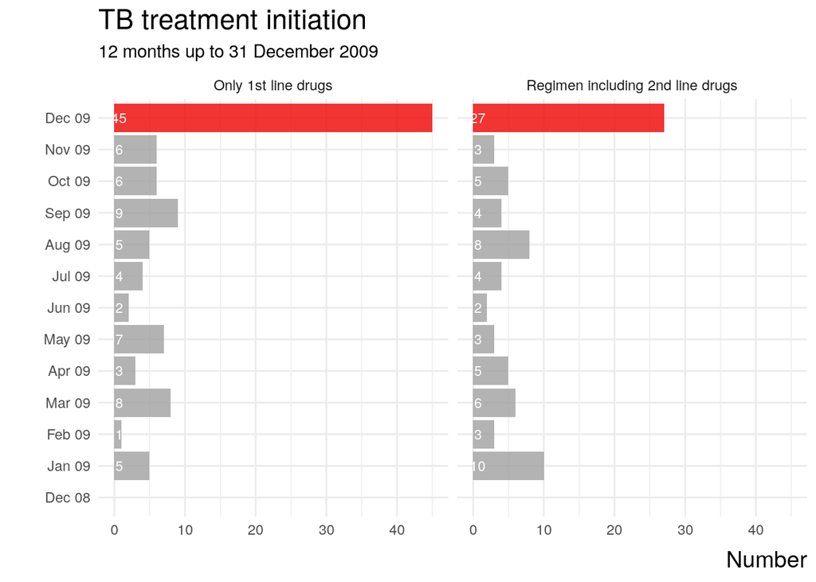

### Quarterly initiations

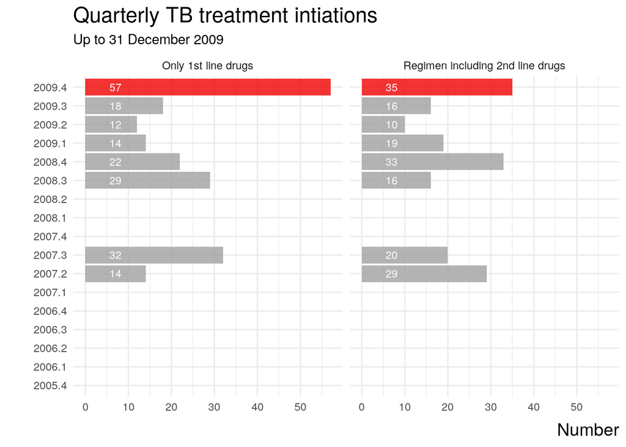

### Definitions

The information in this section aims to summarise programme entry over time. This may be presented by treatment initiation or first consultation. Counts are split into calendar months or quarters and are tabulated and graphically represented. For comparison with more recent information, tables summarising monthly inclusions over the life of a programme are included.

Definition

**Table**  
Summarises the number and percentage of patients included in the cohort by calendar month. Episodes (e.g. treatment initation or pregnancy), rather than individual patients, are counted in this table.

**Monthly & Quarterly plots**  
Monthly and quarterly bar plots visually display programme entry by time period. These counts may be segregated further in some reports (e.g. TB treatment type). This type of plot should quickly illustrate seasonal or temporal changes in programme inclusion

**Key variables**

> Cohort inclusion: Treatment start date

**Key data form**

> Form 2 Treatment Initiation_Début traitement

## Registration characteristics

### Age, gender and BMI

|  | Reporting period N (%) | Reporting period Total | Previous 12 months N (%) | Previous 12 months Total | Full programme N (%) | Full programme Total |
| --- | --- | --- | --- | --- | --- | --- |
| Age: |  | 364 |  | 364 |  | 763 |
| < 15y | 49 (13.5%) |  | 49 (13.5%) |  | 111 (14.5%) |  |
| 15-44y | 105 (28.8%) |  | 105 (28.8%) |  | 222 (29.1%) |  |
| ≥ 45y | 210 (57.7%) |  | 210 (57.7%) |  | 430 (56.4%) |  |
| 'Missing' | 0 (0.0%) |  | 0 (0.0%) |  | 0 (0.0%) |  |
| Gender: |  | 364 |  | 364 |  | 763 |
| Female | 168 (46.2%) |  | 168 (46.2%) |  | 371 (48.6%) |  |
| Male | 195 (53.6%) |  | 195 (53.6%) |  | 387 (50.7%) |  |
| Unknown | 0 (0.0%) |  | 0 (0.0%) |  | 4 (0.5%) |  |
| 'Missing' | 1 (0.3%) |  | 1 (0.3%) |  | 1 (0.1%) |  |
| BMI: |  | 364 |  | 364 |  | 763 |
| ≥ 18.5 | 246 (67.6%) |  | 246 (67.6%) |  | 509 (66.7%) |  |
| < 18.5 | 118 (32.4%) |  | 118 (32.4%) |  | 254 (33.3%) |  |
| 'Missing' | 0 (0.0%) |  | 0 (0.0%) |  | 0 (0.0%) |  |

### Registration and lab confirmation

|  | Reporting period N (%) | Reporting period Total | Previous 12 months N (%) | Previous 12 months Total | Full programme N (%) | Full programme Total |
| --- | --- | --- | --- | --- | --- | --- |
| Registration group: |  | 364 |  | 364 |  | 763 |
| New | 68 (18.7%) |  | 68 (18.7%) |  | 137 (18.0%) |  |
| Relapse | 74 (20.3%) |  | 74 (20.3%) |  | 157 (20.6%) |  |
| Treatment after loss to followup | 55 (15.1%) |  | 55 (15.1%) |  | 130 (17.0%) |  |
| Treatment After Failure | 73 (20.1%) |  | 73 (20.1%) |  | 146 (19.1%) |  |
| Other previously treated patients | 60 (16.5%) |  | 60 (16.5%) |  | 115 (15.1%) |  |
| 'Missing' | 34 (9.3%) |  | 34 (9.3%) |  | 78 (10.2%) |  |
| Lab confirmation: |  | 364 |  | 364 |  | 763 |
| Clinically diagnosed | 158 (43.4%) |  | 158 (43.4%) |  | 348 (45.6%) |  |
| Bacteriologically Confirmed | 175 (48.1%) |  | 175 (48.1%) |  | 336 (44.0%) |  |
| 'Missing' | 31 (8.5%) |  | 31 (8.5%) |  | 79 (10.4%) |  |

### DST results

|  | Reporting period N (%) | Reporting period Total | Previous 12 months N (%) | Previous 12 months Total | Full programme N (%) | Full programme Total |
| --- | --- | --- | --- | --- | --- | --- |
| DST: |  | 329 |  | 329 |  | 676 |
| Confirmed drug resistant TB | 81 (24.6%) |  | 81 (24.6%) |  | 161 (23.8%) |  |
| Confirmed drug susceptible | 82 (24.9%) |  | 82 (24.9%) |  | 174 (25.7%) |  |
| Profile unconfirmed | 95 (28.9%) |  | 95 (28.9%) |  | 185 (27.4%) |  |
| Unknown | 71 (21.6%) |  | 71 (21.6%) |  | 156 (23.1%) |  |
| Detailed DST: |  | 364 |  | 364 |  | 763 |
| H(S) resistance | 36 (9.9%) |  | 36 (9.9%) |  | 69 (9.0%) |  |
| HE(S) resistance | 40 (11.0%) |  | 40 (11.0%) |  | 84 (11.0%) |  |
| R resistance with H susceptibility | 50 (13.7%) |  | 50 (13.7%) |  | 85 (11.1%) |  |
| GeneXpert RIF resistance only | 33 (9.1%) |  | 33 (9.1%) |  | 70 (9.2%) |  |
| Confirmed MDR | 48 (13.2%) |  | 48 (13.2%) |  | 88 (11.5%) |  |
| Confirmed pre-XDR (FQ) | 37 (10.2%) |  | 37 (10.2%) |  | 76 (10.0%) |  |
| Confirmed pre-XDR (Inj) | 29 (8.0%) |  | 29 (8.0%) |  | 82 (10.7%) |  |
| Confirmed XDR | 31 (8.5%) |  | 31 (8.5%) |  | 63 (8.3%) |  |
| Other | 34 (9.3%) |  | 34 (9.3%) |  | 78 (10.2%) |  |
| 'Missing' | 26 (7.1%) |  | 26 (7.1%) |  | 68 (8.9%) |  |

### Definitions

This section includes information recorded from patients when they enter the cohort. Relevant variables are presented for each disease. Three reporting periods have been included - the reporting period defined by the user, the 12 months prior to the end of the user-defined reporting period, and the full programme duration.

**Key data forms**

> New patient registration form  
> 1 History TB_ Antécédents TB

# Treatment outcomes

### Reported between 01 Jan 2009 - 31 Dec 2009

|  | Reporting period DS-TB | Reporting period DR-TB |
| --- | --- | --- |
| Outcome: |  |  |
| Cured | 23 (26.4%) | 20 (23.3%) |
| Completed | 29 (33.3%) | 38 (44.2%) |
| Died | 1 (1.1%) | 2 (2.3%) |
| Failed | 11 (12.6%) | 10 (11.6%) |
| LTFU | 8 (9.2%) | 9 (10.5%) |
| Not Evaluated | 11 (12.6%) | 5 (5.8%) |
| Treatment adapted | 3 (3.4%) | 2 (2.3%) |
| 'Missing' | 1 (1.1%) | 0 (0.0%) |

## Cohort outcome reporting

### DS-TB outcomes by quarter

#### Table

|  | Q4, 2008 N (%) | Q4, 2008 N |
| --- | --- | --- |
| Outcome: |  | 87 |
| Cured | 23 (26.4%) |  |
| Completed | 29 (33.3%) |  |
| Died | 1 (1.1%) |  |
| Failed | 11 (12.6%) |  |
| LTFU | 8 (9.2%) |  |
| Not Evaluated | 11 (12.6%) |  |
| Treatment adapted | 3 (3.4%) |  |
| 'Missing' | 1 (1.1%) |  |

#### Plot

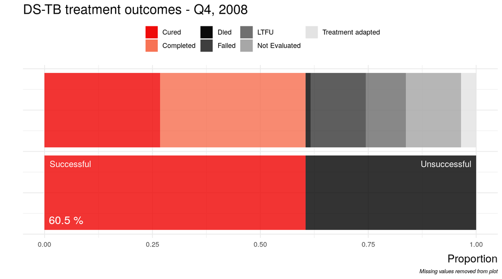

### DR-TB by semester

#### Table

|  | Semester 2, 2007 N (%) | Semester 2, 2007 N | Older programme outcomes N (%) | Older programme outcomes N |
| --- | --- | --- | --- | --- |
| Outcome: |  | 86 |  | 86 |
| Cured | 20 (23.3%) |  | 20 (23.3%) |  |
| Completed | 38 (44.2%) |  | 38 (44.2%) |  |
| Died | 2 (2.3%) |  | 2 (2.3%) |  |
| Failed | 10 (11.6%) |  | 10 (11.6%) |  |
| LTFU | 9 (10.5%) |  | 9 (10.5%) |  |
| Not Evaluated | 5 (5.8%) |  | 5 (5.8%) |  |
| Treatment adapted | 2 (2.3%) |  | 2 (2.3%) |  |
| 'Missing' | 0 (0.0%) |  | 0 (0.0%) |  |

#### Plot

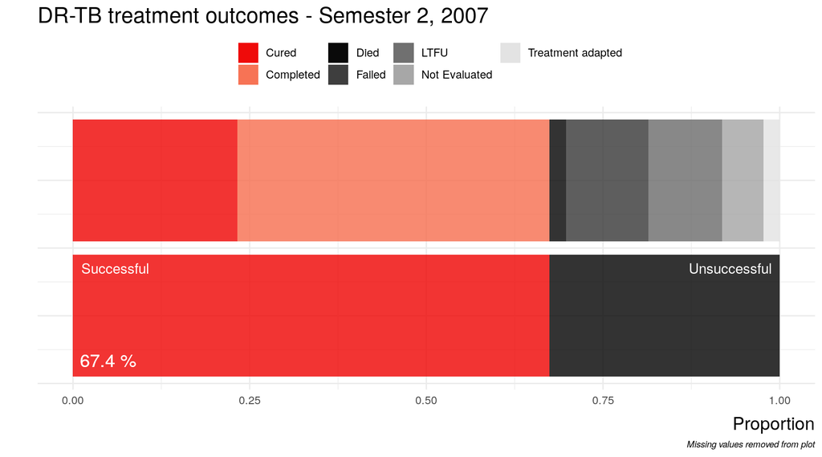

#### Semester outcomes plot

[figure not shown]

### Definitions

This section summarises the end of treatment outcomes through using cohort reporting principles. Treatment cohorts are, by convention, defined by the period of treatment initiation. Treatment initation is included here either as a quarter or semester depending on the disease and treatment type

Definition

**Episode**  
The counts included in this table represent treatment episodes rather than individual patients. Therefore, patients who started treatment more than once during the defined period will be counted multiple times.

**Loss to Follow-up**  
Loss to follow up in this table is based on outcomes recorded during data entry. It has not been calculated through patient attendance records.

**TB treatment cohort**  
The treatment cohort is defined by episodes starting greater than 15 months (for DS-TB) or 30 months (for DR-TB) prior to reporting such that all outcomes should be available.

**Key data form**

> Form 6 Treatment Outcome TB _ Issue du traitement TB